# DNase Dataset Exploration using Mixed Models

# Data Exploration

The DNase dataset in R is a collection of data in the development of an assay. According to the R documentation,

An object of class c(“nfnGroupedData”, “nfGroupedData”, “groupedData”, “data.frame”) containing the following columns:

Run - an ordered factor with levels 10 < … < 3 indicating the assay run. conc - a numeric vector giving the known concentration of the protein. density - a numeric vector giving the measured optical density (dimensionless) in the assay. Duplicate optical density measurements were obtained.

The description for the factors `Run` is not exactly correct as the ordered factors includes 11

```r
unique(DNase$Run)
```

```
 [1] 1  2  3  4  5  6  7  8  9  10 11
Levels: 10 < 11 < 9 < 1 < 4 < 8 < 5 < 7 < 6 < 2 < 3
```

What does the data look like “raw”

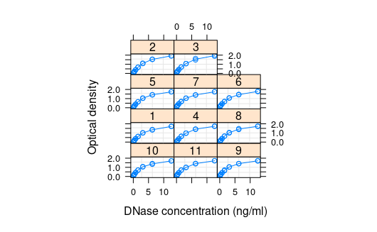

```r
plot(DNase)
```

What we see is that there are duplicates in the density row. What is their structure?

```r
head(DNase, 10)
```

```
Grouped Data: density ~ conc | Run
   Run       conc density
1    1 0.04882812   0.017
2    1 0.04882812   0.018
3    1 0.19531250   0.121
4    1 0.19531250   0.124
5    1 0.39062500   0.206
6    1 0.39062500   0.215
7    1 0.78125000   0.377
8    1 0.78125000   0.374
9    1 1.56250000   0.614
10   1 1.56250000   0.609
```

The duplicate density measurement occur in pairs of identical protein concentration. Let’s look at the density as a function of concentration.

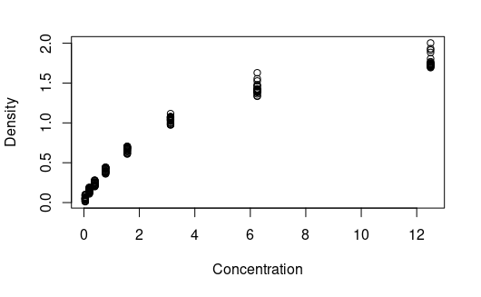

```r
plot(
    x=DNase$conc,
    y=DNase$density,
    xlab="Concentration",
    ylab="Density"
)
```

The trend indicates there is saturation limit, unless the true growth is logarithmic. For modeling purposes, let’s consider logistic growth. What does a logistic model look like? For this analysis, let’s use the self start model as we will want the gradient calculation also.

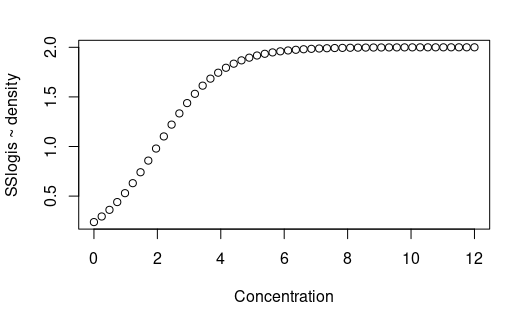

```r
input_seq <- seq(0, 12, length.out=50)

initial_pars <- c(
    Asym = 2.0,
    xmid = 2.0,
    scal = 1.0
)

plot(
    input_seq,
    SSlogis(
        input_seq,
        Asym=initial_pars[["Asym"]],
        xmid=initial_pars[["xmid"]],
        scal=initial_pars[["scal"]]
    ),
    xlab="Concentration",
    ylab="SSlogis ~ density"
)
```

I would characterize this model as sufficient given some optimization. Given the density measurements are in pairs, let’s split the data frame into training and testing sets.

```r
train_seq <- seq(1, nrow(DNase)-1, by=2)
test_seq <- seq(2, nrow(DNase), by=2)

if (nrow(DNase) %% 2 == 1){
    train_seq <- c(train_seq, nrow(DNase))
}

DNase_train <- DNase[train_seq,]
DNase_test <- DNase[test_seq, ]
```

Are the train and test sets fundamentally different?

```r
library(testthat)
expect_true(nrow(DNase_train)==nrow(DNase_test))

suppressWarnings(train_test_diff <- DNase_train - DNase_test)

# First the col mean
suppressWarnings(print(colMeans(train_test_diff)))
```

```
        Run        conc     density
         NA 0.000000000 0.005863636
```

```r
# All the conc measurements match 1-to-1
expect_true(all(train_test_diff$conc == 0))

# What is the std-dev, and mean-stddev ratio?
print(sd(train_test_diff$density))
```

```
[1] 0.02960086
```

```r
print(mean(train_test_diff$density) / sd(train_test_diff$density))
```

```
[1] 0.19809
```

Let’s now try to fit a logistic model `SSlogis` to the entire training dataset naively.

$Y = \frac{\text{A}}{1+\exp{\left[\phi^{-1}\left(x_0-X\right)\right]}}$

where $Y$ is the density, $A$ is the asymptotic value, $x_0$ is the inflection point, $\phi$ is the scale, and $X$ is the concentration.

```r
model_fit <- nls(
    density ~ SSlogis(conc, Asym, xmid, scal),
    data = DNase_train,
    start = initial_pars
)

summary(model_fit)
```

```
Formula: density ~ SSlogis(conc, Asym, xmid, scal)

Parameters:
     Estimate Std. Error t value Pr(>|t|)
Asym  1.64814    0.02866   57.52   <2e-16 ***
xmid  2.40984    0.09603   25.09   <2e-16 ***
scal  1.20857    0.06884   17.56   <2e-16 ***
---
Signif. codes:  0 ‘***’ 0.001 ‘**’ 0.01 ‘*’ 0.05 ‘.’ 0.1 ‘ ’ 1

Residual standard error: 0.1177 on 85 degrees of freedom

Number of iterations to convergence: 11
Achieved convergence tolerance: 7.873e-06
```

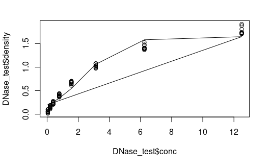

```r
model_predictions <- predict(
    model_fit,
    DNase_train$conc
)
plot(DNase_test$conc, DNase_test$density)
lines(DNase_train$conc, model_predictions)
```

There are some sloppy bookkeeping as the first and last line points intersect, but that is OK as we want to get a feel for the model.

What does each level fit have to tell us? Does each `Run` have a similar fit quality?

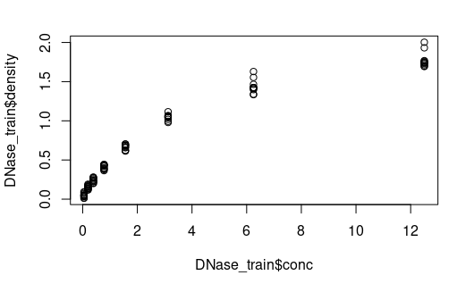

```r
plot(DNase_train$conc, DNase_train$density, col="black", xlim=range(DNase$conc), ylim=range(DNase$density))
```

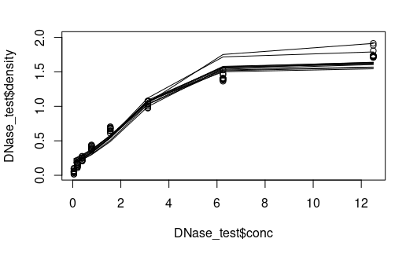

```r
plot(DNase_test$conc, DNase_test$density, col="black", xlim=range(DNase$conc), ylim=range(DNase$density))
for(run_level in unique(DNase_train$Run)){
    train_data_for_model <- DNase_train[DNase_train$Run == run_level, ]
    test_data_for_model <- DNase_test[DNase_test$Run == run_level, ]
    temp_model_fit <- nls(
        density ~ SSlogis(conc, Asym, xmid, scal),
        data = train_data_for_model,
        start = initial_pars
    )
    temp_model_predictions <- predict(
        temp_model_fit,
        test_data_for_model$conc
    )
    lines(test_data_for_model$conc, temp_model_predictions)
}
```

# Mixed Models

Let’s try to fit a nonlinear mixed model with a single random effect over the training set. The library that I will use is the `lme4`.

```r
library(lme4)
```

I will include the same non-linear model with a random additive magnitude $u$

$Y = \frac{\text{A+u}}{1+\exp{\left[\phi^{-1}\left(x_0-X\right)\right]}}$

which is a random effects vector where $u \sim \mathcal{N}\left(0, \Sigma\right)$

```r
DNase_train$Run <- as.numeric(DNase_train$Run)

mixed_model <- nlmer(
    density ~ SSlogis(conc, Asym, xmid, scal) ~ (Asym|Run),
    data = DNase_train,
    start = initial_pars
)

nm1a <- update(mixed_model, nAGQ = 0L)
```

```r
summary(nm1a)
```

```
Nonlinear mixed model fit by maximum likelihood  ['nlmerMod']
Formula: density ~ SSlogis(conc, Asym, xmid, scal) ~ (Asym | Run)
   Data: DNase_train

     AIC      BIC   logLik deviance df.resid
  -119.8   -107.5     64.9   -129.8       83

Scaled residuals:
    Min      1Q  Median      3Q     Max
-2.1366 -0.8482 -0.1270  0.6783  3.0490

Random effects:
 Groups   Name Variance  Std.Dev.
 Run      Asym 8.551e-05 0.009247
 Residual      1.336e-02 0.115588
Number of obs: 88, groups:  Run, 11

Fixed effects:
     Estimate Std. Error t value
Asym  1.64811    0.02827   58.30
xmid  2.40966    0.09427   25.56
scal  1.20846    0.06757   17.88

Correlation of Fixed Effects:
     Asym  xmid
xmid 0.627
scal 0.421 0.651
```

Let’s examine the fixed-effects parameters against the test set

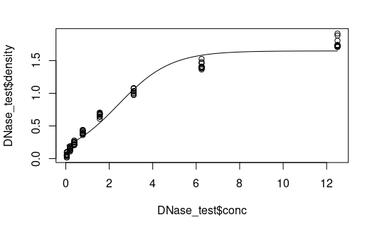

```r
nm1a_fexef <- fixef(nm1a)
conc_range <- range(DNase$conc)
plot_seq <- seq(conc_range[1], conc_range[2], length.out = 50)
plot(DNase_test$conc, DNase_test$density)

lines(
    plot_seq,
    SSlogis(
        plot_seq,
        nm1a_fexef[["Asym"]],
        nm1a_fexef[["xmid"]],
        nm1a_fexef[["scal"]]
    )
)
```

So how did the assay `Run` samples, the random effect, impact the fit?

```r
raef_out <- ranef(nm1a)$Run

raef_df <- data.frame(
    mean=raef_out[, "Asym"],
    std=rep(sigma(nm1a), nrow(raef_out))

)
raef_df
```

| mean | std |
| --- | --- |
| -9.664731e-04 | 0.115588 |
| -5.782381e-04 | 0.115588 |
| -8.545847e-04 | 0.115588 |
| -1.257621e-03 | 0.115588 |
| -8.303876e-04 | 0.115588 |
| -9.331794e-05 | 0.115588 |
| -2.715032e-04 | 0.115588 |
| -6.149713e-05 | 0.115588 |
| 1.127866e-04 | 0.115588 |
| 1.944411e-03 | 0.115588 |

[output cut: 1 more lines]

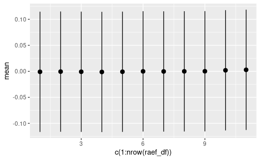

```r
library(ggplot2)

raef_plot <- ggplot(
    raef_df,
    aes(
        x=c(1:nrow(raef_df)),
        y=mean,
        ymin=mean-std,
        ymax=mean+std
    )
)
    # + geom_line()
    # + geom_point()
    # + geom_errorbar(aes(ymin=mean-std, ymax=mean+std), width=.2,
                 # position=position_dodge(0.05))

# print(raef_plot)
raef_plot + geom_pointrange()
```

```r
colMeans(raef_df)
```

```
         mean           std
-1.071882e-19  1.155880e-01
```

As expected, the expectation of the random effect vector $E[u] = 0$.

Turns out that the standard deviation of the random effect is much larger than the effect itself. Essentially, we see that the `Run` random effect is minimal using this model.

# Afterthoughts

Another iteration of this analysis could study the identical density measurements as a significant random effect. This would entail creating a new factor like `fdensity` that takes on the levels c(1:2). To avoid over fitting, the training and testing sets would be the sub-samples of the `Run` factor.